# VEGANScreener + metabolomics

Q2: Associations between VS_total and the metabolome in vegans.

**This script explores patterns in the metabolome profiles of vegans, particularly by linking them to the VEGANScreener score (VS_total).**

The script is divided into two parts, based on how the metabolome datasets were integrated (see the preprocessing scripts for details). The first part analyzes the **sPCA dataset**, which is used for multivariate analysis, PCA visualization, PERMANOVA, and the machine-learning models. The second part uses the **concatenated dataset** (LC-MS and NMR combined) for the univariate analysis.

The analysis is composed of the following main parts:

1. Global visualization — the first three components, color-coded by **VS_total**.
2. PERMANOVA — how much of the variation can be explained by various external variables: dist(Metabolome) ~ sex + bmi + age + veganDuration + country***VS_total**
3. Univariate analysis (feature-wise model) — linear modelling of each metabolite against various external variables: Metabolite ~ sex + bmi + age + veganDuration + Country***VS_total**
4. Random forest (RF) classification — the model is trained and validated by bootstrapping with 500 iterations, and used to distinguish between participants in the **1st and 3rd tertiles of VS_total**. Two types of models are trained:
1. a model on the original sPCA dataset
2. a model on the sPCA dataset after regressing out the covariates.

# 1 Import

```r
metadata_df <- read.table(
  file =  "../../data/preprocessed/metadata_preprocessed_v3.tsv",
  header = TRUE)

lcms_df <- read.table(
  file= "../../data/preprocessed/metabolomics/lc_ms_preprocessed_INT_v3.tsv",
  check.names = FALSE)

nmr_df <- read.table(
  file = "../../data/preprocessed/metabolomics/nmr_preprocessed_INT_v3.tsv",
  check.names = FALSE)

spca_integrated_df <-  read.table(
  file = "../../data/preprocessed/metabolomics/spca_integrated_vegans_INT_v3.tsv",
  check.names = FALSE)
```

**Scaling** — when metadata columns are used as covariates, they need to be scaled so that each has a mean of 0 and a standard deviation of 1.

```r
metadata_scaled_df <- metadata_df
metadata_scaled_df[,-c(1,3,5,6,8)] <- apply(metadata_df[,-c(1,3,5,6,8)],2,scale)
metadata_scaled_df <- metadata_scaled_df %>%
  mutate(sex=as.factor(sex),
         country=as.factor(country),
         group=as.factor(group),
         diet_supplements=as.factor(diet_supplements))
```

# 2 Descriptive statistics

```r
metadata_df %>% dplyr::group_by(country,sex) %>% count()
```

```
# A tibble: 10 × 3
# Groups:   country, sex [10]
   country sex       n
   <chr>   <chr> <int>
 1 BE      F        54
 2 BE      M        28
 3 CH      F        23
 4 CH      M        20
 5 CZ      F        50
 6 CZ      M        41
 7 DE      F        51
 8 DE      M        47
 9 ES      F        28
10 ES      M        15
```

Basic plots showing the distribution of selected variables:

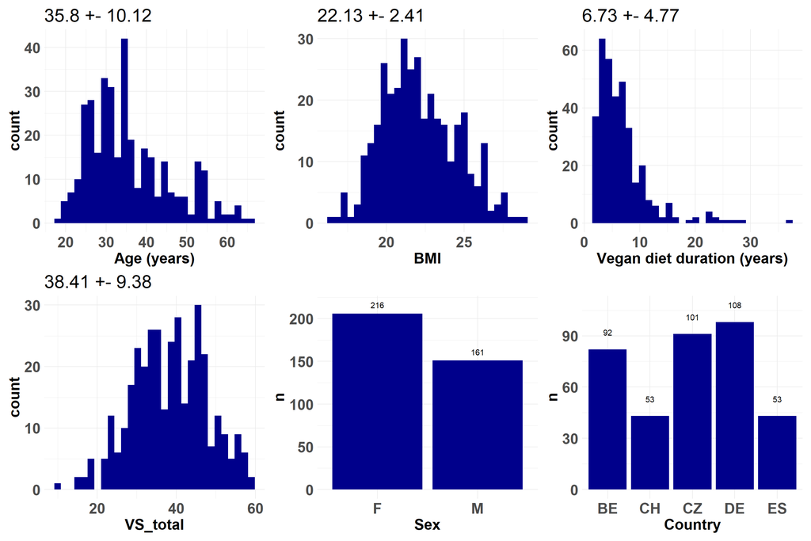

```r
plot_list <- list()
name <- c("Age (years)","BMI","Vegan diet duration (years)","VS_total")
i <- 1
for (col in c("age","bmi","vegan_duration","VS_total")){
  p <- ggplot(metadata_df) +
    geom_histogram(aes(x=!!sym(col)),fill="darkblue") +
    theme_minimal() +
    theme(axis.title = element_text(face="bold",size=20),
          axis.text=element_text(face="bold",size=20),
          title = element_text(face = "plain",size=20)) +
    xlab(name[i]) +
    ggtitle(paste(round(mean(metadata_df[,col],na.rm = TRUE),2),"+-", round(sd(metadata_df[,col],na.rm = TRUE),2)))

  plot_list[[length(plot_list)+1]] <- p
  i <- i + 1

}
i <- 1
name <- c("Sex","Country")
for (col in c("sex","country")){
  p <- ggplot(metadata_df) +
        theme_minimal() +
     theme(axis.title = element_text(face="bold",size=20),
          axis.text=element_text(face="bold",size=20)) +
    stat_count(aes(x=!!sym(col)),fill="darkblue") +
  geom_text(data=metadata_df %>%
              dplyr::group_by(!!sym(col)) %>% count() %>%
              dplyr::mutate(n=n+10), aes(x=!!sym(col),y=n,label=n)) +
    xlab(name[i])

  plot_list[[length(plot_list)+1]] <- p

  i <- i+1
}

wrap_plots(plot_list)
```

# 3 SPCA

The sPCA dataset was created by concatenating the LC-MS and NMR datasets and applying the mixOmics::spca() function. See the preprocessing script for details.

mixOmics::spca() performs **sparse Principal Component Analysis (sPCA)**, which works like regular PCA but adds a sparsity constraint so that only a subset of variables contributes to each component. The degree of sparsity is controlled by a penalization term, which makes the components easier to interpret because irrelevant or noisy variables are given loadings of zero.

## 3.1 Visualization

### 3.1.1 PCA

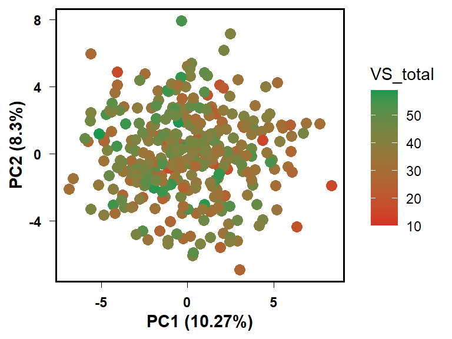

```r
spca_plot_df <- merge(
  spca_integrated_df %>% rownames_to_column("study_id"),
  metadata_df,by="study_id")

p <- pca_plot(spca_integrated_df,
              metadata_df,
              color_col = "VS_total",
              perform_pca = FALSE)

p <- ggtheme(p)

p
```

```r
p_pca <- list()
p_pca[[1]] <- p
```

```r
f2a <- p
save(f2a,file="../results/vegan/figures/f2a.RData")
```

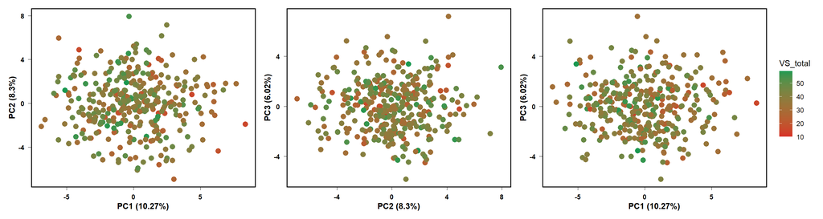

```r
spca_plot_df <- merge(
  spca_integrated_df %>% rownames_to_column("study_id"),
  metadata_df,by="study_id")

p1 <- pca_plot(spca_integrated_df,
              metadata_df,
              color_col = "VS_total",
              perform_pca = FALSE,axis = c("PC1","PC2"))

p1 <- ggtheme(p1)

p2 <- pca_plot(spca_integrated_df,
              metadata_df,
              color_col = "VS_total",
              perform_pca = FALSE,axis = c("PC2","PC3"))

p2 <- ggtheme(p2)

p3 <- pca_plot(spca_integrated_df,
              metadata_df,
              color_col = "VS_total",
              perform_pca = FALSE,axis = c("PC1","PC3"))

p3 <- ggtheme(p3)

p1 + p2 + p3 +
plot_layout(guides = "collect")
```

### 3.1.2 Boxplots

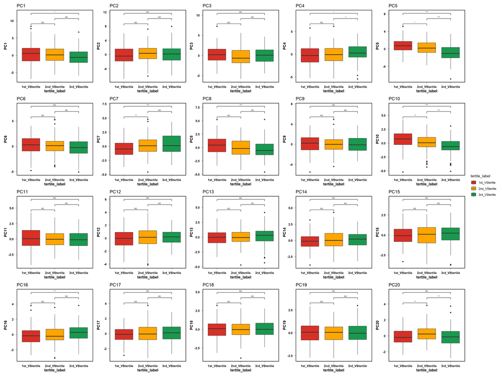

```r
spca_for_uni <- merge(spca_integrated_df %>% rownames_to_column("study_id"),
                      metadata_scaled_df,by="study_id",all = TRUE)

spca_for_uni <- spca_for_uni %>%
  mutate(
    tertile_cut = ntile(VS_total, 3), # assign 1, 2, or 3 (tertile)
    tertile_label = case_when(                          # label tertiles
      tertile_cut == 1 ~ "1st_VStertile",
      tertile_cut == 2 ~ "2nd_VStertile",
      tertile_cut == 3 ~ "3rd_VStertile"
    )
  )

plot_list <- list()
for (col in colnames(spca_integrated_df)){
  p <- ggplot(spca_for_uni,
              aes_string(x = "tertile_label",y = col,fill="tertile_label")) +
    geom_boxplot() +
    ggtitle(col) +
    theme_minimal() +
    scale_fill_manual(values = c("#D73027","orange","#1A9850")) +
    geom_signif(comparisons =
                  combn(as.character(unique(spca_for_uni$tertile_label)),
                        m=2, simplify = FALSE),
                map_signif_level = TRUE, step_increase = 0.1,textsize = 2)

  p <- ggtheme(p)
  plot_list[[length(plot_list) + 1]] <- p
}


a <- wrap_plots(plot_list,guides = "collect")

a
```

### 3.1.3 Heatmap

```r
metadata_df <- metadata_df %>%
  mutate(
    tertile_cut = ntile(VS_total, 3), # assign 1, 2, or 3 (tertile)
    tertile_label = case_when(                          # label tertiles
      tertile_cut == 1 ~ "1st_VStertile",
      tertile_cut == 2 ~ "2nd_VStertile",
      tertile_cut == 3 ~ "3rd_VStertile"
    )
  ) %>%
  dplyr::select(-tertile_cut)
```

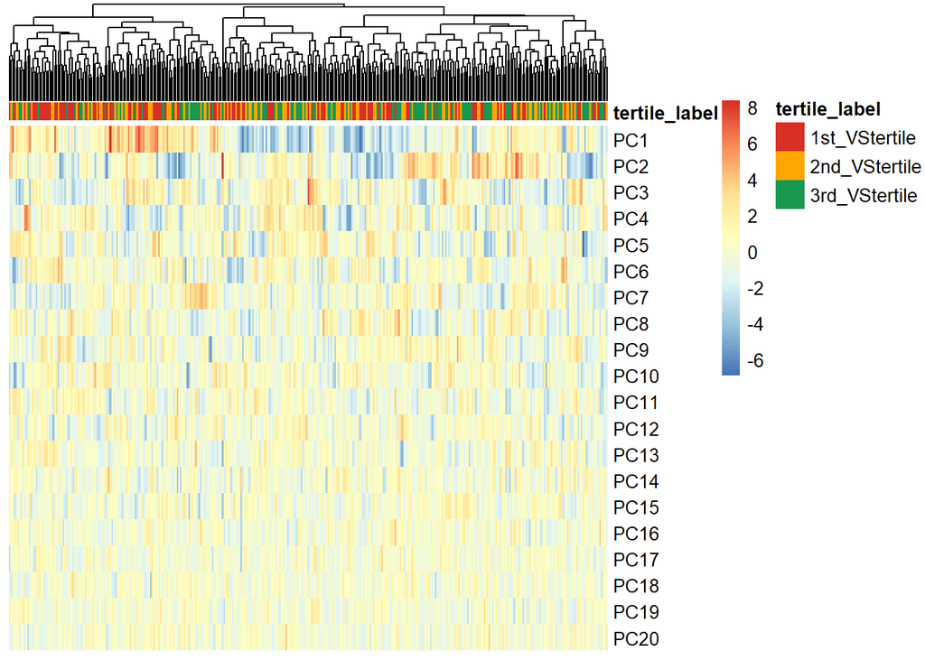

```r
VS_colors <- c("1st_VStertile"="#D73027",
               "2nd_VStertile"="orange",
               "3rd_VStertile"="#1A9850")

p_df <- spca_integrated_df %>% t()

ann_df <- metadata_df %>% dplyr::select(study_id,tertile_label) %>%
  column_to_rownames("study_id")

ann_colors <- list(
  "tertile_label"=VS_colors
)
names(ann_colors[["tertile_label"]]) <- names(VS_colors)

p <- pheatmap(p_df,cluster_rows = FALSE,show_colnames = FALSE,
              annotation_col = ann_df,
              annotation_colors = ann_colors,silent = TRUE)

p
```

**Tertile averages**

```r
metadata_df %>%
  dplyr::select(VS_total, tertile_label) %>%
  group_by(tertile_label) %>%
  summarise(mean_VS = mean(VS_total, na.rm = TRUE))
```

```
# A tibble: 3 × 2
  tertile_label mean_VS
  <chr>           <dbl>
1 1st_VStertile    28.1
2 2nd_VStertile    38.4
3 3rd_VStertile    48.8
```

## 3.2 PERMANOVA

The test shows how much of the variation in the metabolome is explained by sex, age, BMI, vegan duration, country, and **VS_total**.

However, country of origin still explains the largest share of the variation, around **10%**. The interaction effect is not significant, suggesting that the effect of VS_total is consistent across countries.

```r
# Create Euclidean distance matrix
dist_mat <- vegdist(spca_integrated_df,
                    method = "euclidean")

# Test whether vegan vs omnivore differ in metabolomics
adonis_result <- adonis2(
  dist_mat ~ sex + bmi + age + vegan_duration + country*VS_total,
  data = metadata_scaled_df ,
  permutations = 999,
  by="terms")

print(adonis_result)
```

```
Permutation test for adonis under reduced model
Terms added sequentially (first to last)
Permutation: free
Number of permutations: 999

adonis2(formula = dist_mat ~ sex + bmi + age + vegan_duration + country * VS_total, data = metadata_scaled_df, permutations = 999, by = "terms")
                  Df SumOfSqs      R2       F Pr(>F)
sex                1   1103.5 0.05624 24.3791  0.001 ***
bmi                1    168.6 0.00859  3.7249  0.001 ***
age                1    250.8 0.01278  5.5413  0.001 ***
vegan_duration     1     52.2 0.00266  1.1538  0.264
country            4   1860.1 0.09480 10.2736  0.001 ***
VS_total           1    510.6 0.02602 11.2803  0.001 ***
country:VS_total   4    149.7 0.00763  0.8270  0.830
Residual         343  15525.4 0.79127
Total            356  19620.9 1.00000
---
Signif. codes:  0 '***' 0.001 '**' 0.01 '*' 0.05 '.' 0.1 ' ' 1
```

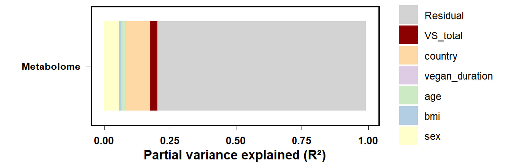

```r
adonis_result <- adonis_result[-c(7,9),] %>% rownames_to_column("Var")
adonis_result$Var <- factor(adonis_result$Var,levels = rev(c("sex","bmi","age", "vegan_duration","country","VS_total", "Residual")))
p <- ggplot(adonis_result, aes(fill=Var, x=R2, y="Metabolome")) +
    geom_bar(position="stack", stat="identity") +
  ylab("") + xlab("Partial variance explained (R²)") +
  scale_fill_manual(values=rev(c("#ffffcc","#b3cde3","#ccebc5",
                                 "#decbe4","#fed9a6","darkred",
                                 "lightgrey")),name = "Covariate")

p <- ggtheme(p)

p
```

```r
p_pca[[2]] <- p
p_pca[[3]] <- adonis_result
```

## 3.3 RF model

### 3.3.1 Original model

```r
sub_metadata_df <- metadata_df %>%
dplyr::filter(
  tertile_label %in% c("1st_VStertile","3rd_VStertile"))

sub_spca_integrated_df <- spca_integrated_df[as.character(sub_metadata_df$study_id),]
```

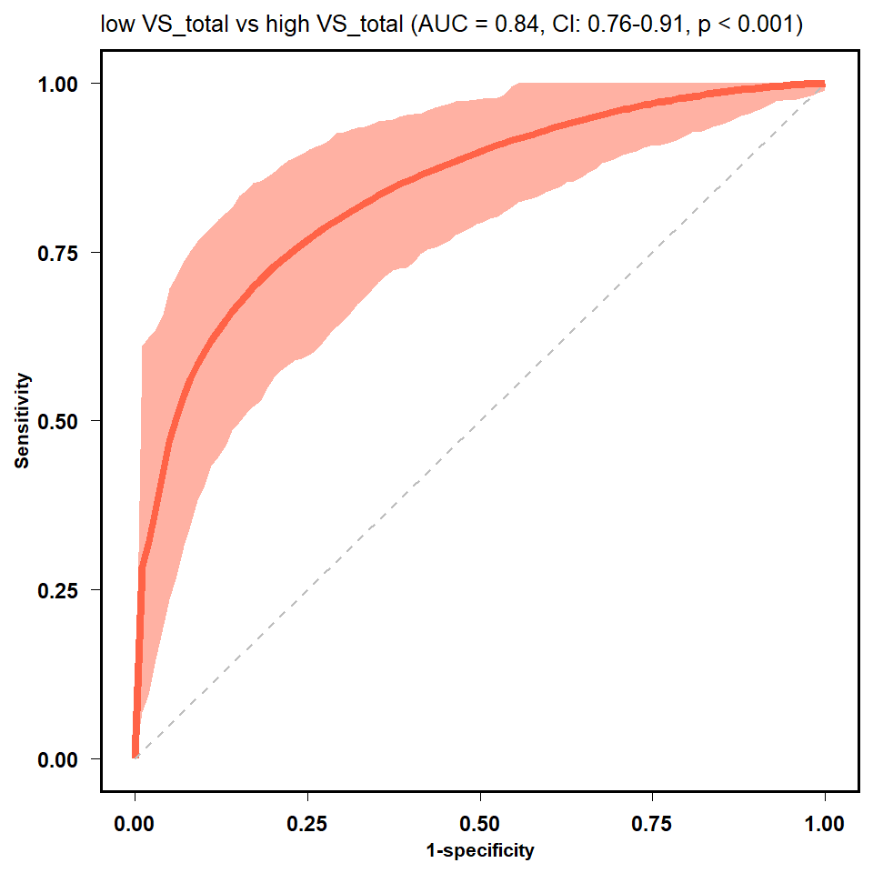

```r
model_name <- "VS_tertile_vegan"

prepared_df <- model_preparation(sub_spca_integrated_df,
                                 sub_metadata_df,
                                 predicting_col = "tertile_label")

rf_model <- make_rf_model(data=prepared_df,
                            outcome="Group",
                            N = 500,
                           file = model_name,
                            reuse=TRUE)

roc_c <- roc_curve(model_object = rf_model,
                   group = c("low VS_total","high VS_total"),CI = TRUE)

roc_c <- ggtheme(roc_c) +
  theme(legend.position="none",title = element_text(size=8))

roc_c
```

**Accuracy**

```r
# Find the "best" threshold using Youden's J Index
# This maximizes (Sensitivity + Specificity - 1)
roc_obj <- rf_model$rocobj
best_threshold_data <- coords(roc_obj, "best",
                              ret = "threshold",
                              best.method = "youden")
optimal_threshold <- best_threshold_data$threshold
optimal_threshold
```

```
[1] 0.5078667
```

```r
# saving the results
save_rf_details("../results/vegan/RF_models_performance.xlsx",model_name,rf_model)
```

```
[1] "Results saved to ../results/vegan/RF_models_performance.xlsx"
```

### 3.3.2 Adjusted model

```r
# Covariates to adjust for
covars <- c("sex","bmi", "age", "country", "vegan_duration")
integrated_df <- sub_spca_integrated_df
all(rownames(integrated_df) == sub_metadata_df$study_id)
```

```
[1] TRUE
```

```r
adjusted_data <- adjust_for_covars(integrated_df, covars, sub_metadata_df)

model_name <- "adjusted_vstotal_model_vegan"

prepared_df <- model_preparation(adjusted_data,
                                 sub_metadata_df,
                                 predicting_col = "tertile_label")

rf_model <- make_rf_model(data=prepared_df,
                          outcome="Group",
                          N = 500,
                          file = model_name,
                          reuse=TRUE)

rf_model$model_summary
```

```
  mtry splitrule min.node.size       auc  accuracy   auc_CIL   auc_CIU
1    3      gini             5 0.7284584 0.6634269 0.6365813 0.8072274
  accuracy_CIL accuracy_CIU
1    0.5797538    0.7426318
```

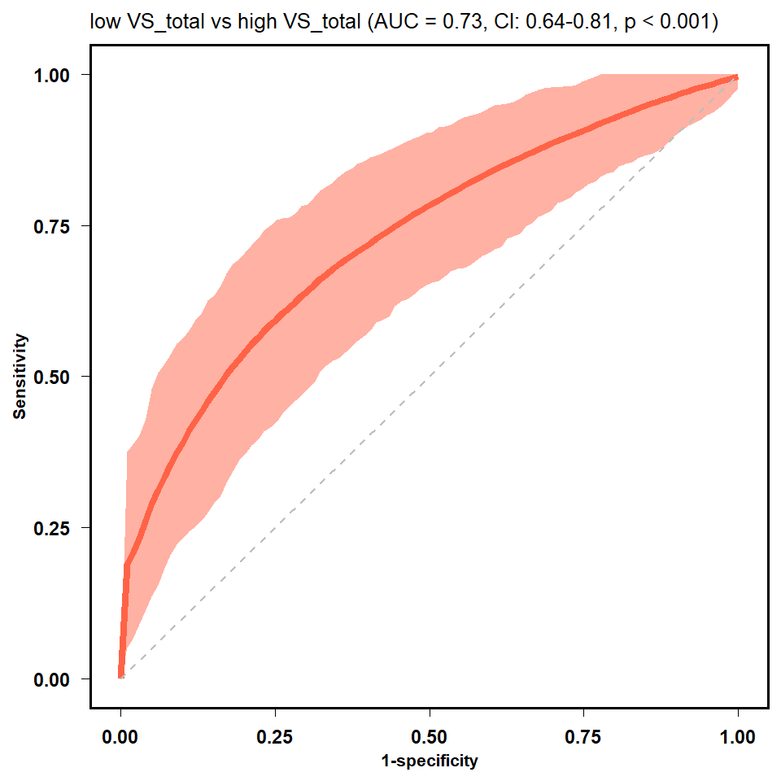

```r
roc_c <- roc_curve(model_object = rf_model,
                   group = c("low VS_total","high VS_total"),CI = TRUE)

roc_c <- ggtheme(roc_c) +
  theme(legend.position="none",title = element_text(size=8))

roc_c
```

```r
f2b <- roc_c
save(f2b,file="../results/vegan/figures/f2b.RData")
```

```r
# Find the "best" threshold using Youden's J Index
# This maximizes (Sensitivity + Specificity - 1)
roc_obj <- rf_model$rocobj
best_threshold_data <- coords(roc_obj, "best",
                              ret = "threshold",
                              best.method = "youden")
optimal_threshold <- best_threshold_data$threshold
optimal_threshold
```

```
[1] 0.4855833
```

```r
# saving the results
save_rf_details("../results/vegan/RF_models_performance.xlsx",model_name,rf_model)
```

```
[1] "Results saved to ../results/vegan/RF_models_performance.xlsx"
```

## 3.4 RF importance

### 3.4.1 Original model

**PC5** and **PC10** are the most important variables for the RF model.

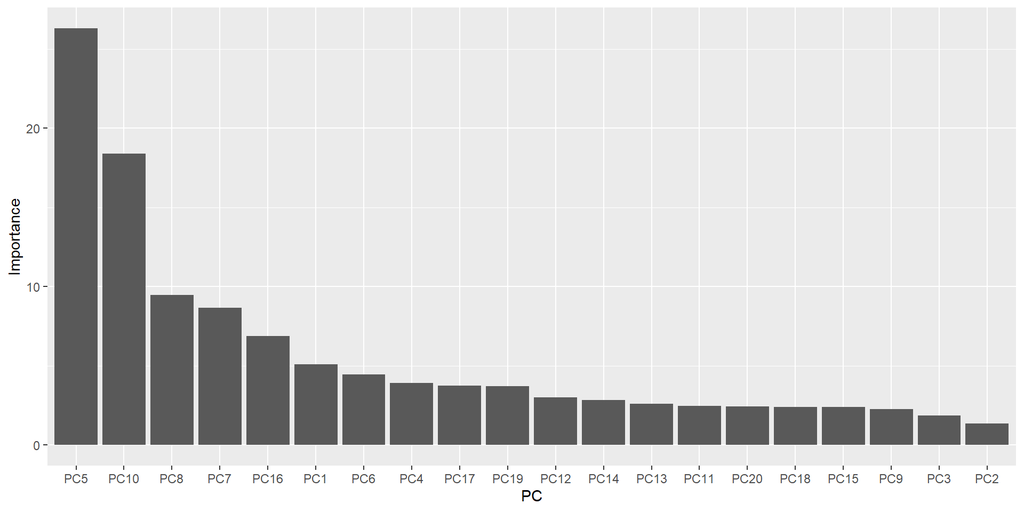

```r
load("../intermediate_files/models/VS_tertile_vegan/rf_model.RData")

var_imp <- as.data.frame(importance(rf_model$trained_model)) %>%
  rownames_to_column("PC") %>%
  `colnames<-`(c("PC","Importance"))

var_imp <- var_imp %>% dplyr::mutate(PC=factor(PC,levels = PC[order(var_imp$Importance,decreasing = TRUE)]))

ggplot(var_imp) +
  geom_col(aes(x=PC,y=Importance))
```

### 3.4.2 Adjusted model

As above, **PC5** is the most important variable, with a marked drop in importance for the PCs after it.

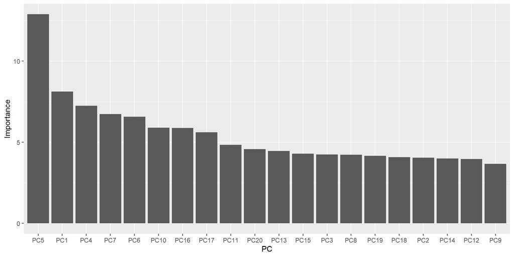

```r
load("../intermediate_files/models/adjusted_vstotal_model_vegan/rf_model.RData")

var_imp <- as.data.frame(importance(rf_model$trained_model)) %>%
  rownames_to_column("PC") %>%
  `colnames<-`(c("PC","Importance"))

var_imp <- var_imp %>% dplyr::mutate(PC=factor(PC,levels = PC[order(var_imp$Importance,decreasing = TRUE)]))

ggplot(var_imp) +
  geom_col(aes(x=PC,y=Importance))
```

### 3.4.3 Visualization

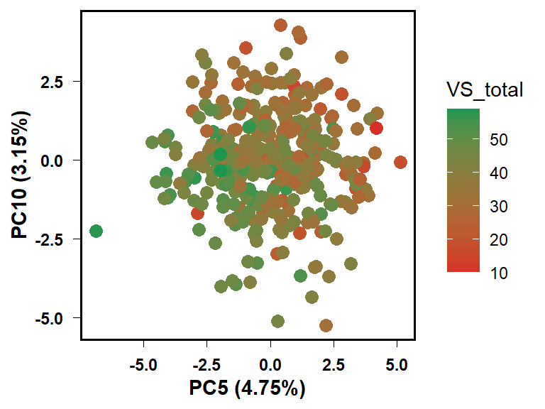

```r
spca_plot_df <- merge(
  spca_integrated_df %>% rownames_to_column("study_id"),
  metadata_df,by="study_id")

p <- pca_plot(spca_integrated_df,
              metadata_df,
              color_col = "VS_total",
              perform_pca = FALSE,
              axis = c("PC5","PC10"))

p <- ggtheme(p)

p
```

```r
p_pca[[4]] <- p
```

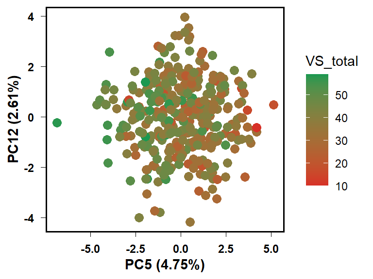

```r
spca_plot_df <- merge(
  spca_integrated_df %>% rownames_to_column("study_id"),
  metadata_df,by="study_id")

p <- pca_plot(spca_integrated_df,
              metadata_df,
              color_col = "VS_total",
              perform_pca = FALSE,
              axis = c("PC5","PC12"))

p <- ggtheme(p)

p
```

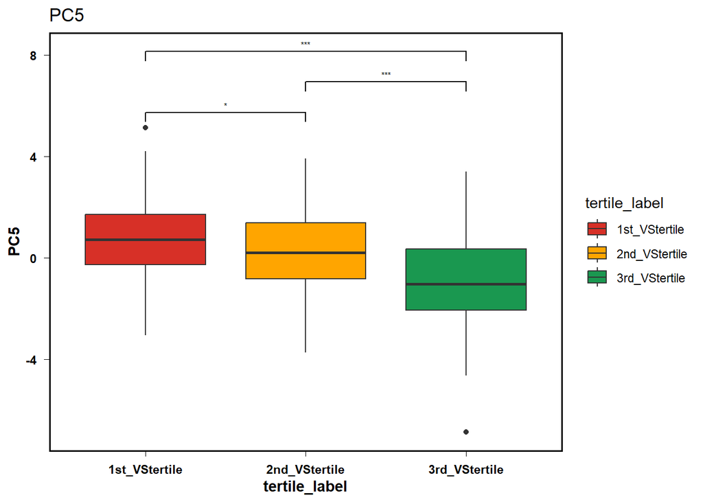

```r
p <- ggplot(spca_for_uni,
             aes_string(x = "tertile_label",y = "PC5",fill="tertile_label")) +
    geom_boxplot() +
    ggtitle("PC5") +
    theme_minimal() +
    scale_fill_manual(values = c("#D73027","orange","#1A9850")) +
    geom_signif(comparisons =
                  combn(as.character(unique(spca_for_uni$tertile_label)),
                        m=2, simplify = FALSE),
                map_signif_level = TRUE, step_increase = 0.1,textsize = 2)

p <- ggtheme(p)

p
```

## 3.5 SPCA loadings

Here, we explore the loadings of the most important PC (**PC5**).

```r
load("../results/preprocessing/spca_result_vegans_INT_v3.RData")
df <- data.frame (
  Metabolite=names(spca_result$loadings$X[,5]),
  Loading=spca_result$loadings$X[,5])

write.table(df,sep="\t","../results/vegan/Q2_VStotal/loadings_PC5.tsv")
```

This plot shows the loadings of individual metabolites on **PC5**, ordered by absolute value.

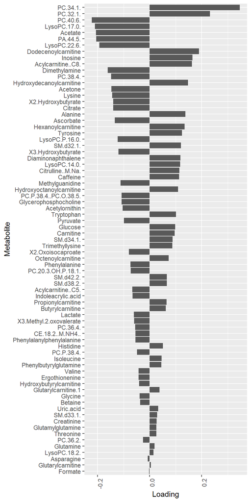

```r
ggplot(df %>%
         dplyr::mutate(
           Metabolite=factor(Metabolite,
                             levels = Metabolite[order(abs(Loading),decreasing = FALSE)])
           )) +
  geom_col(aes(x=Metabolite,y=Loading)) +
  theme(axis.text.x = element_text(angle=90,hjust = 1)) +
  coord_flip()
```

```r
spca_loadings <- df$Metabolite[abs(df$Loading)>=0.1]
```

# 4 Concatenated dataset

```r
concat_integrated_df <- cbind(lcms_df,nmr_df)
```

## 4.1 Visualization

### 4.1.1 Boxplots

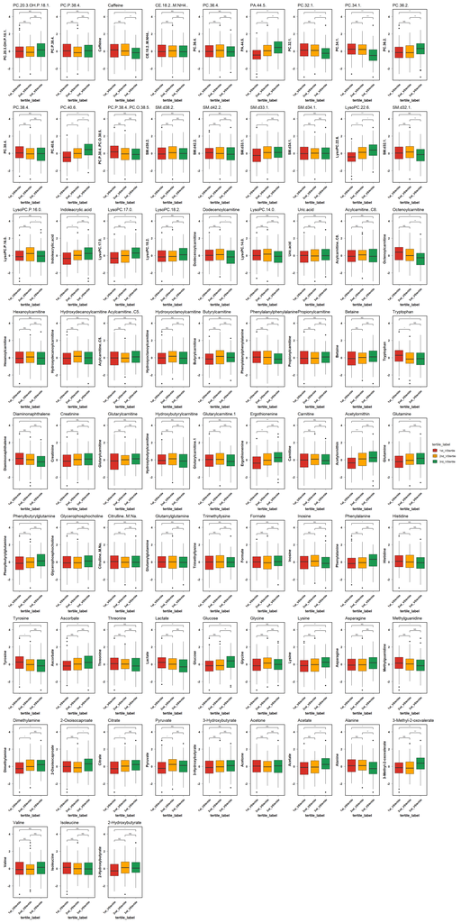

```r
concat_for_uni <- merge(concat_integrated_df %>% rownames_to_column("study_id"),
                      metadata_scaled_df,by="study_id",all = TRUE)

concat_for_uni <- concat_for_uni %>%
  mutate(
    tertile_cut = ntile(VS_total, 3), # assign 1, 2, or 3 (tertile)
    tertile_label = case_when(                          # label tertiles
      tertile_cut == 1 ~ "1st_VStertile",
      tertile_cut == 2 ~ "2nd_VStertile",
      tertile_cut == 3 ~ "3rd_VStertile"
    )
  )

plot_list <- list()
for (col in colnames(concat_integrated_df)){
  p <- ggplot(concat_for_uni,
              aes(x = tertile_label,
                  y = !!sym(col),
                  fill=tertile_label)) +
    geom_boxplot() +
    ggtitle(col) +
    theme_minimal() +
    scale_fill_manual(values = c("#D73027","orange","#1A9850")) +
    geom_signif(comparisons =
                  combn(as.character(unique(concat_for_uni$tertile_label)),
                        m=2, simplify = FALSE),
                map_signif_level = TRUE, step_increase = 0.1,textsize = 2)

  p <- ggtheme(p) +
    theme(axis.text.x = element_text(angle=45,hjust = 1))
  plot_list[[length(plot_list) + 1]] <- p
}


a <- wrap_plots(plot_list,guides = "collect")

a
```

### 4.1.2 Heatmap

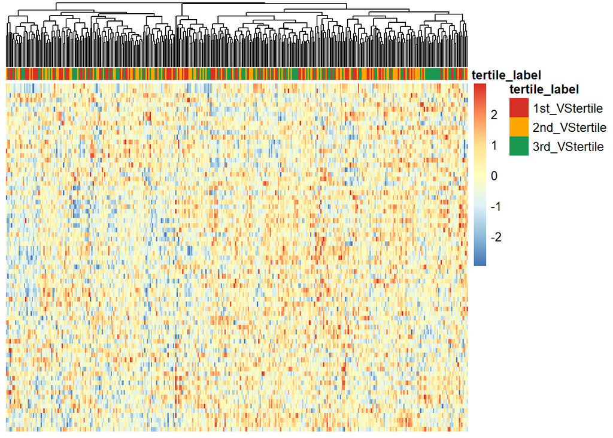

```r
VS_colors <- c("1st_VStertile"="#D73027",
               "2nd_VStertile"="orange",
               "3rd_VStertile"="#1A9850")

p_df <- concat_integrated_df %>% t()

ann_df <- metadata_df %>% dplyr::select(study_id,tertile_label) %>%
  column_to_rownames("study_id")

ann_colors <- list(
  "tertile_label"=VS_colors
)
names(ann_colors[["tertile_label"]]) <- names(VS_colors)

p <- pheatmap(p_df,cluster_rows = FALSE,show_colnames = FALSE,
              show_rownames = FALSE,
              annotation_col = ann_df,
              annotation_colors = ann_colors,silent = TRUE)

p
```

## 4.2 Univariate analysis

We test the differences between diets and VS_total using a generalized linear model, while adjusting for covariates.

### 4.2.1 Metabolite-wise model

#### 4.2.1.1 Continuous analysis

Metabolite ~ sex + bmi + age + eq_vegan_dur_total + Country*VS_total

```r
results_list <- lapply(colnames(concat_integrated_df),
                       function(x) fit_glm(x,concat_for_uni,
                                           tested_variable = "VS_total"))
results_df <- do.call(rbind, results_list)

results_df$p_adjusted <- p.adjust(results_df$Pr...t..,method = "BH")
```

Significant results — **9 metabolites**:

```r
results_df %>%
  dplyr::filter(p_adjusted<0.05) %>%
  dplyr::filter(variable=="VS_total")
```

```
          metabolite variable   Estimate Std..Error   t.value     Pr...t..
1           PA.44.5. VS_total  0.3745633  0.1057681  3.541365 4.530696e-04
2           PC.34.1. VS_total -0.4465378  0.1083447 -4.121456 4.725605e-05
3           PC.40.6. VS_total  0.3621233  0.1051670  3.443315 6.457739e-04
4          SM.d42.2. VS_total -0.3310033  0.1166010 -2.838768 4.798612e-03
5       LysoPC.22.6. VS_total  0.4485308  0.1067844  4.200339 3.401528e-05
6 Indoleacrylic.acid VS_total  0.4363235  0.1082761  4.029731 6.881966e-05
7       LysoPC.17.0. VS_total  0.3250241  0.1121652  2.897726 4.000414e-03
8     Ergothionenine VS_total  0.3091748  0.1093372  2.827718 4.963409e-03
9     Acetylornithin VS_total  0.4058296  0.1115711  3.637408 3.176932e-04
    p_adjusted
1 0.0054680817
2 0.0007876008
3 0.0073702455
4 0.0362485106
5 0.0005760653
6 0.0011089440
7 0.0317403105
8 0.0372255710
9 0.0039711648
```

```r
results_all <- (results_df %>%
  dplyr::filter(variable=="VS_total"))

# save
write.table(results_all,"../results/vegan/Q2_VStotal//lm_continous_all.tsv",
            row.names = FALSE,
            quote=FALSE,
            sep="\t")
```

Interaction effect — **none**:

```r
df <- results_df %>%
  dplyr::filter(p_adjusted<0.05) %>%
  dplyr::filter(str_ends(variable, ":VS_total"))

df
```

```
[1] metabolite variable   Estimate   Std..Error t.value    Pr...t..   p_adjusted
<0 rows> (or 0-length row.names)
```

```r
pc_to_be_removed <- df$metabolite
```

```r
concat_significant_df <- (results_df %>%
  dplyr::filter(p_adjusted<0.05) %>%
  dplyr::filter(variable=="VS_total"))

concat_univariate_results <- results_df

concat_significant <- (results_df %>%
  dplyr::filter(p_adjusted<0.05) %>%
  dplyr::filter(variable=="VS_total"))$metabolite

# save and show
write.table(concat_significant_df,"../results/vegan/Q2_VStotal//lm_continous.tsv",
            row.names = FALSE,
            quote=FALSE,
            sep="\t")

knitr::kable(concat_significant)
```

| x |
| --- |
| PA.44.5. |
| PC.34.1. |
| PC.40.6. |
| SM.d42.2. |
| LysoPC.22.6. |
| Indoleacrylic.acid |
| LysoPC.17.0. |
| Ergothionenine |
| Acetylornithin |

**Volcano plot**

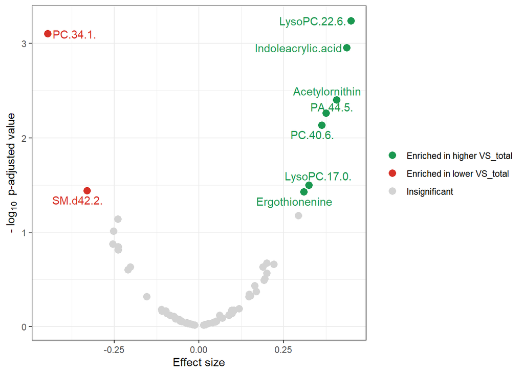

```r
vp <- volcano_plot(results_df,comparison = "VS_total")
vp
```

**Correlation**

```r
sign <- (results_df %>%
  dplyr::filter(p_adjusted<0.05) %>%
  dplyr::filter(variable=="VS_total"))$metabolite
```

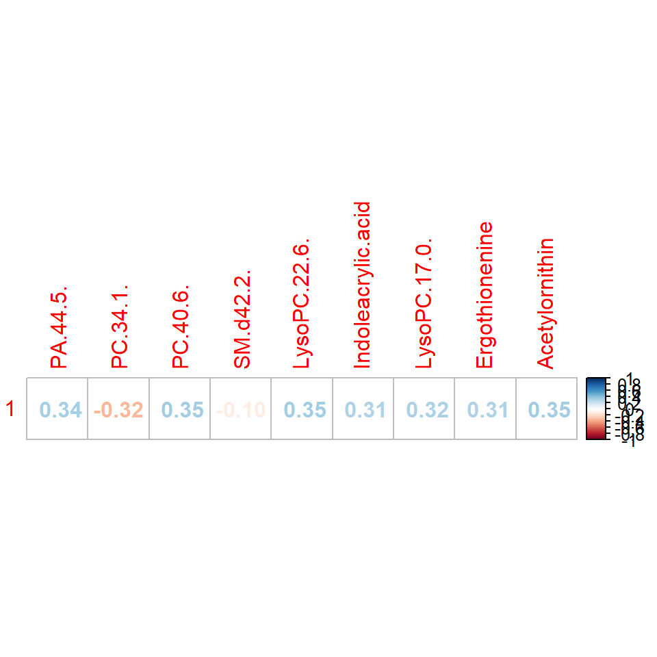

```r
df_for_plot <- concat_integrated_df %>% dplyr::select(sign)
corr_object <- cor(concat_for_uni$VS_total,df_for_plot)
corrplot::corrplot(corr_object,method = "number")
```

**Vegan duration**

```r
results_df %>%
  dplyr::filter(p_adjusted<0.05) %>%
  dplyr::filter(variable=="vegan_duration")
```

```
          metabolite       variable  Estimate Std..Error  t.value    Pr...t..
1 Indoleacrylic.acid vegan_duration 0.1637206 0.05321483 3.076597 0.002262178
  p_adjusted
1 0.02047661
```

### 4.2.2 Pairwise analysis

Metab ~ sex + bmi + age + eq_vegan_dur_total + Country + tertile_label

**LM**

```r
results_list <- lapply(colnames(concat_integrated_df),
                       function(x) fit_netglm(x,concat_for_uni,
                                           tested_variable = "tertile_label"))
results_df <- do.call(rbind, results_list)

vs_effects <- results_df %>%
  dplyr::mutate(p_adj = p.adjust(`p.value`, method = "BH"))

concat_significant_cat <-  vs_effects %>%
  filter(p_adj < 0.05)

# save and show
write.table(concat_significant_cat,"../results/vegan/Q2_VStotal//lm_cat.tsv",
            row.names = FALSE,
            quote=FALSE,
            sep="\t")

knitr::kable(concat_significant_cat)
```

| metabolite | tertile_label | emmean | p.value | lower.CL | upper.CL | p_adj |
| --- | --- | --- | --- | --- | --- | --- |
| Caffeine | 3rd_VStertile | -0.2926469 | 0.0022626 | -0.4797496 | -0.1055442 | 0.0236792 |
| PA.44.5. | 1st_VStertile | -0.4390839 | 0.0000009 | -0.6113230 | -0.2668449 | 0.0000382 |
| PC.32.1. | 3rd_VStertile | -0.3911327 | 0.0000585 | -0.5801821 | -0.2020833 | 0.0013154 |
| PC.34.1. | 1st_VStertile | 0.3285162 | 0.0003314 | 0.1503081 | 0.5067243 | 0.0057359 |
| PC.34.1. | 3rd_VStertile | -0.4582083 | 0.0000010 | -0.6392769 | -0.2771397 | 0.0000382 |
| PC.36.2. | 3rd_VStertile | 0.2696962 | 0.0054664 | 0.0799640 | 0.4594284 | 0.0397220 |
| PC.40.6. | 1st_VStertile | -0.3818457 | 0.0000158 | -0.5533623 | -0.2103290 | 0.0004453 |
| LysoPC.22.6. | 1st_VStertile | -0.4571294 | 0.0000004 | -0.6308931 | -0.2833657 | 0.0000291 |
| SM.d32.1. | 3rd_VStertile | -0.4266261 | 0.0000024 | -0.6014658 | -0.2517863 | 0.0000763 |
| Indoleacrylic.acid | 1st_VStertile | -0.2677935 | 0.0037824 | -0.4484498 | -0.0871371 | 0.0315199 |
| Indoleacrylic.acid | 3rd_VStertile | 0.2971214 | 0.0015859 | 0.1135652 | 0.4806776 | 0.0187804 |
| LysoPC.17.0. | 3rd_VStertile | 0.2925456 | 0.0023153 | 0.1050774 | 0.4800138 | 0.0236792 |
| LysoPC.18.2. | 3rd_VStertile | 0.3172811 | 0.0007666 | 0.1334569 | 0.5011053 | 0.0101461 |
| LysoPC.14.0. | 3rd_VStertile | -0.2828941 | 0.0033365 | -0.4711610 | -0.0946273 | 0.0300282 |
| Octenoylcarnitine | 3rd_VStertile | -0.4842972 | 0.0000000 | -0.6414708 | -0.3271235 | 0.0000004 |
| Hydroxydecanoylcarnitine | 2nd_VStertile | 0.2836641 | 0.0014970 | 0.1093613 | 0.4579668 | 0.0187120 |
| Hydroxyoctanoylcarnitine | 2nd_VStertile | 0.2516156 | 0.0056185 | 0.0740263 | 0.4292049 | 0.0397220 |
| Ergothionenine | 1st_VStertile | -0.2703842 | 0.0034953 | -0.4512275 | -0.0895409 | 0.0302474 |
| Ergothionenine | 3rd_VStertile | 0.3360618 | 0.0003684 | 0.1523157 | 0.5198078 | 0.0059213 |
| Acetylornithin | 1st_VStertile | -0.3929497 | 0.0000326 | -0.5765350 | -0.2093643 | 0.0008153 |
| Acetylornithin | 3rd_VStertile | 0.3280765 | 0.0006092 | 0.1415443 | 0.5146086 | 0.0085667 |
| Formate | 1st_VStertile | 0.3353946 | 0.0000005 | 0.2062332 | 0.4645561 | 0.0000304 |
| Formate | 2nd_VStertile | 0.1768476 | 0.0058938 | 0.0513132 | 0.3023819 | 0.0401848 |
| Formate | 3rd_VStertile | 0.2436849 | 0.0003003 | 0.1124502 | 0.3749196 | 0.0056299 |
| Phenylalanine | 3rd_VStertile | 0.2859686 | 0.0032709 | 0.0960588 | 0.4758783 | 0.0300282 |
| Tyrosine | 1st_VStertile | 0.2577740 | 0.0055252 | 0.0761993 | 0.4393487 | 0.0397220 |
| Ascorbate | 1st_VStertile | -0.2590138 | 0.0030489 | -0.4297472 | -0.0882804 | 0.0298264 |
| Dimethylamine | 1st_VStertile | -0.2901436 | 0.0020262 | -0.4736377 | -0.1066496 | 0.0227946 |
| 2-Oxoisocaproate | 3rd_VStertile | 0.3184832 | 0.0004745 | 0.1409522 | 0.4960142 | 0.0071168 |
| Acetate | 3rd_VStertile | 0.2460455 | 0.0068991 | 0.0679958 | 0.4240952 | 0.0456559 |
| Alanine | 3rd_VStertile | -0.2721447 | 0.0050816 | -0.4619661 | -0.0823233 | 0.0397220 |
| 3-Methyl-2-oxovalerate | 3rd_VStertile | 0.5259614 | 0.0000000 | 0.3568345 | 0.6950882 | 0.0000004 |
| Valine | 3rd_VStertile | 0.2411476 | 0.0056493 | 0.0708354 | 0.4114597 | 0.0397220 |
| 2-Hydroxybutyrate | 1st_VStertile | -0.3446528 | 0.0002792 | -0.5292828 | -0.1600229 | 0.0056299 |

```r
results_all <- vs_effects

# save
write.table(results_all,"../results/vegan/Q2_VStotal/lm_emmeans_all.tsv",
            row.names = FALSE,
            quote=FALSE,
            sep="\t")
```

**Dispersion**

```r
dispersion <- vs_effects %>%
  group_by(metabolite) %>%
  summarise(
    range      = max(emmean) - min(emmean),      # simplest: spread between highest and lowest
    sd         = sd(emmean),                      # standard deviation of the 5 country means
    cv         = sd(emmean) / abs(mean(emmean)),  # coefficient of variation (relative dispersion)
    min_mean   = min(emmean),
    max_mean   = max(emmean),
    min_VS = tertile_label[which.min(emmean)],
    max_VS = tertile_label[which.max(emmean)]
  ) %>%
  arrange(desc(range))

dispersion
```

```
# A tibble: 75 × 8
   metabolite             range    sd     cv min_mean max_mean min_VS     max_VS
   <chr>                  <dbl> <dbl>  <dbl>    <dbl>    <dbl> <fct>      <fct>
 1 PC.34.1.               0.787 0.407 106.     -0.458    0.329 3rd_VSter… 1st_V…
 2 Acetylornithin         0.721 0.374  14.7    -0.393    0.328 1st_VSter… 3rd_V…
 3 LysoPC.22.6.           0.686 0.350   4.66   -0.457    0.229 1st_VSter… 3rd_V…
 4 3-Methyl-2-oxovalerate 0.671 0.350   2.63   -0.145    0.526 1st_VSter… 3rd_V…
 5 PA.44.5.               0.620 0.312   2.83   -0.439    0.181 1st_VSter… 3rd_V…
 6 Octenoylcarnitine      0.614 0.314   2.26   -0.484    0.130 3rd_VSter… 1st_V…
 7 Ergothionenine         0.606 0.309   4.69   -0.270    0.336 1st_VSter… 3rd_V…
 8 Indoleacrylic.acid     0.565 0.288   6.23   -0.268    0.297 1st_VSter… 3rd_V…
 9 PC.40.6.               0.563 0.282   3.05   -0.382    0.181 1st_VSter… 3rd_V…
10 PC.32.1.               0.532 0.277   3.44   -0.391    0.141 3rd_VSter… 1st_V…
# ℹ 65 more rows
```

```r
write.table(dispersion,"../results/vegan/Q2_VStotal/dispersion.tsv",sep="\t",row.names = FALSE,quote=FALSE)
```

```r
results_list_pairwise <- lapply(colnames(concat_integrated_df),
                       function(x) fit_netglm_pairwise(x,concat_for_uni,
                                           tested_variable = "tertile_label"))
results_df_pairwise <- do.call(rbind, results_list_pairwise)

vs_effects_pairwise <- results_df_pairwise %>%
  dplyr::mutate(p_adj = p.adjust(`p.value`, method = "BH"))

vs_significant_pairwise <-  vs_effects_pairwise %>%
  filter(p_adj < 0.05)
```

#### 4.2.2.1 Heatmap

```r
df2 <- vs_effects_pairwise %>%
  mutate(
    contrast = gsub("_VStertile", "", contrast),
    signif = p_adj < 0.05
  )

df2$Significance <- ifelse(df2$p_adj<0.001,"***",
                                       ifelse(df2$p_adj<0.01,"**",
                                              ifelse(df2$p_adj<0.05,"*","")))
```

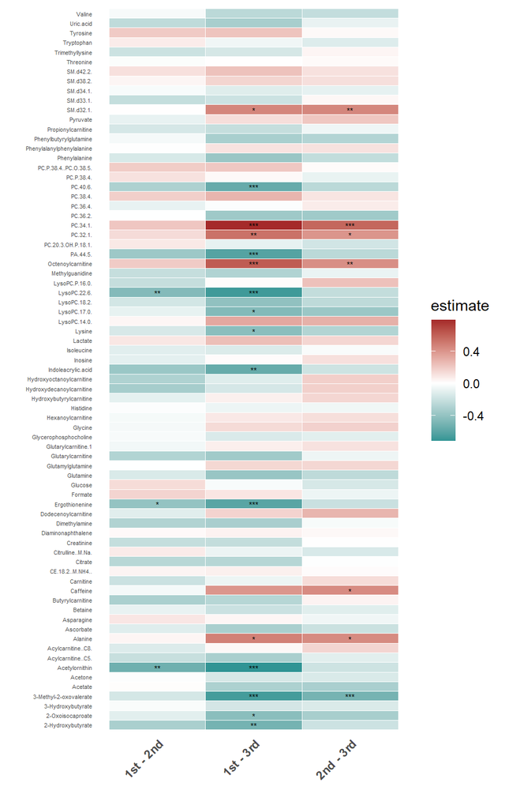

```r
p_pairwise_heatmap <- ggplot(df2, aes(x = contrast, y = Metabolite, fill = estimate)) +
  geom_tile(color = "white") +
  geom_text(aes(label = Significance,vjust=0.6), color = "black", size = 2) +
  scale_fill_gradient2(
    low = "darkcyan", mid = "white", high = "brown", midpoint = 0) +
  theme_minimal() +
  theme(axis.text.y = element_text(size=4),
        axis.text.x = element_text(angle = 45,face="bold",hjust = 1),
        panel.grid = element_blank()) +
  xlab("") + ylab("")

p_pairwise_heatmap
```

Network construction:

#### 4.2.2.2 Network construction

**Edge list**

```r
edges <- vs_effects %>%
  filter(p_adj < 0.05) %>%
  #filter(abs(emmean)>0.3) %>%
  dplyr::select(from = tertile_label, to = metabolite,
         emmean = emmean) %>%
  dplyr::mutate(from=as.character(from),
         weight=abs(emmean))

edges$from <- as.character(edges$from)
edges$to   <- as.character(edges$to)
```

**Nodes table**

```r
tertiles <- as.character(unique(edges$from))
metabs <- as.character(unique(edges$to))

nodes <- data.frame(
  name = c(tertiles, metabs),
  type = c(rep(TRUE, length(tertiles)), rep(FALSE, length(metabs))) # TRUE = tertile, FALSE = metabolite
)
```

**Build igraph object**

```r
g <- graph_from_data_frame(d = edges, vertices = nodes, directed = FALSE)
```

**Visualize**

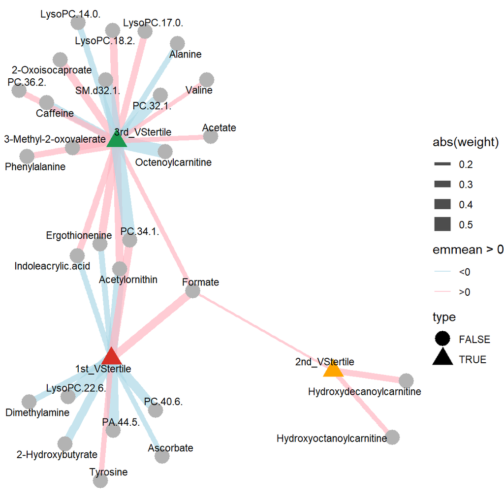

```r
VS_colors <- c("1st_VStertile"="#D73027",
               "2nd_VStertile"="orange",
               "3rd_VStertile"="#1A9850")

# Assign colors to nodes: countries get their color, metabolites gray
V(g)$color <- ifelse(V(g)$type,
                     VS_colors[V(g)$name],
                     "gray70")

set.seed(123)
ggraph(g, layout = "fr") +
  geom_edge_link(aes(width = abs(weight), color = emmean > 0), alpha = 0.7) +
  scale_edge_color_manual(values = c("lightblue", "lightpink"), labels = c("<0", ">0")) +
  geom_node_point(aes(shape=type,color = name), size = 6) +
  scale_color_manual(values = setNames(V(g)$color, V(g)$name)) +  # node colors
  geom_node_text(aes(label = name), repel = TRUE, size = 3) +
  theme_void() +
  guides(color = "none")
```

#### 4.2.2.3 Degree calculation

```r
# Calculate degree
deg <- degree(g, mode = "all")

# Add to node dataframe
node_degree_df <- data.frame(
  name = names(deg),
  degree = deg,
  type = V(g)$type
)

# Separate interpretation
vs_nodes <- node_degree_df %>% dplyr::filter(type == TRUE)
metabolite_nodes <- node_degree_df %>% dplyr::filter(type == FALSE)

vs_nodes %>% arrange(desc(degree))
```

```
                       name degree type
3rd_VStertile 3rd_VStertile     19 TRUE
1st_VStertile 1st_VStertile     12 TRUE
2nd_VStertile 2nd_VStertile      3 TRUE
```

```r
metabolite_nodes %>% arrange(desc(degree))
```

```
                                             name degree  type
Formate                                   Formate      3 FALSE
PC.34.1.                                 PC.34.1.      2 FALSE
Indoleacrylic.acid             Indoleacrylic.acid      2 FALSE
Ergothionenine                     Ergothionenine      2 FALSE
Acetylornithin                     Acetylornithin      2 FALSE
Caffeine                                 Caffeine      1 FALSE
PA.44.5.                                 PA.44.5.      1 FALSE
PC.32.1.                                 PC.32.1.      1 FALSE
PC.36.2.                                 PC.36.2.      1 FALSE
PC.40.6.                                 PC.40.6.      1 FALSE
LysoPC.22.6.                         LysoPC.22.6.      1 FALSE
SM.d32.1.                               SM.d32.1.      1 FALSE
LysoPC.17.0.                         LysoPC.17.0.      1 FALSE
LysoPC.18.2.                         LysoPC.18.2.      1 FALSE
LysoPC.14.0.                         LysoPC.14.0.      1 FALSE
Octenoylcarnitine               Octenoylcarnitine      1 FALSE
Hydroxydecanoylcarnitine Hydroxydecanoylcarnitine      1 FALSE
Hydroxyoctanoylcarnitine Hydroxyoctanoylcarnitine      1 FALSE
Phenylalanine                       Phenylalanine      1 FALSE
Tyrosine                                 Tyrosine      1 FALSE
Ascorbate                               Ascorbate      1 FALSE
Dimethylamine                       Dimethylamine      1 FALSE
2-Oxoisocaproate                 2-Oxoisocaproate      1 FALSE
Acetate                                   Acetate      1 FALSE
Alanine                                   Alanine      1 FALSE
3-Methyl-2-oxovalerate     3-Methyl-2-oxovalerate      1 FALSE
Valine                                     Valine      1 FALSE
2-Hydroxybutyrate               2-Hydroxybutyrate      1 FALSE
```

**Weighted degree** - reflects the cumulative magnitude of associations, not just the number of links.

```r
strength_vals <- strength(g, weights = E(g)$weight)

node_strength_df <- data.frame(
  name = names(strength_vals),
  strength = strength_vals,
  type = V(g)$type
)

# Separate interpretation
vs_nodes <- node_strength_df %>% dplyr::filter(type == TRUE)
metabolite_nodes <- node_strength_df %>% dplyr::filter(type == FALSE)

vs_nodes %>% arrange(desc(strength))
```

```
                       name  strength type
3rd_VStertile 3rd_VStertile 6.3100235 TRUE
1st_VStertile 1st_VStertile 4.0246813 TRUE
2nd_VStertile 2nd_VStertile 0.7121272 TRUE
```

```r
metabolite_nodes %>% arrange(desc(strength))
```

```
                                             name  strength  type
PC.34.1.                                 PC.34.1. 0.7867245 FALSE
Formate                                   Formate 0.7559271 FALSE
Acetylornithin                     Acetylornithin 0.7210261 FALSE
Ergothionenine                     Ergothionenine 0.6064459 FALSE
Indoleacrylic.acid             Indoleacrylic.acid 0.5649149 FALSE
3-Methyl-2-oxovalerate     3-Methyl-2-oxovalerate 0.5259614 FALSE
Octenoylcarnitine               Octenoylcarnitine 0.4842972 FALSE
LysoPC.22.6.                         LysoPC.22.6. 0.4571294 FALSE
PA.44.5.                                 PA.44.5. 0.4390839 FALSE
SM.d32.1.                               SM.d32.1. 0.4266261 FALSE
PC.32.1.                                 PC.32.1. 0.3911327 FALSE
PC.40.6.                                 PC.40.6. 0.3818457 FALSE
2-Hydroxybutyrate               2-Hydroxybutyrate 0.3446528 FALSE
2-Oxoisocaproate                 2-Oxoisocaproate 0.3184832 FALSE
LysoPC.18.2.                         LysoPC.18.2. 0.3172811 FALSE
Caffeine                                 Caffeine 0.2926469 FALSE
LysoPC.17.0.                         LysoPC.17.0. 0.2925456 FALSE
Dimethylamine                       Dimethylamine 0.2901436 FALSE
Phenylalanine                       Phenylalanine 0.2859686 FALSE
Hydroxydecanoylcarnitine Hydroxydecanoylcarnitine 0.2836641 FALSE
LysoPC.14.0.                         LysoPC.14.0. 0.2828941 FALSE
Alanine                                   Alanine 0.2721447 FALSE
PC.36.2.                                 PC.36.2. 0.2696962 FALSE
Ascorbate                               Ascorbate 0.2590138 FALSE
Tyrosine                                 Tyrosine 0.2577740 FALSE
Hydroxyoctanoylcarnitine Hydroxyoctanoylcarnitine 0.2516156 FALSE
Acetate                                   Acetate 0.2460455 FALSE
Valine                                     Valine 0.2411476 FALSE
```

#### 4.2.2.4 Forest plot

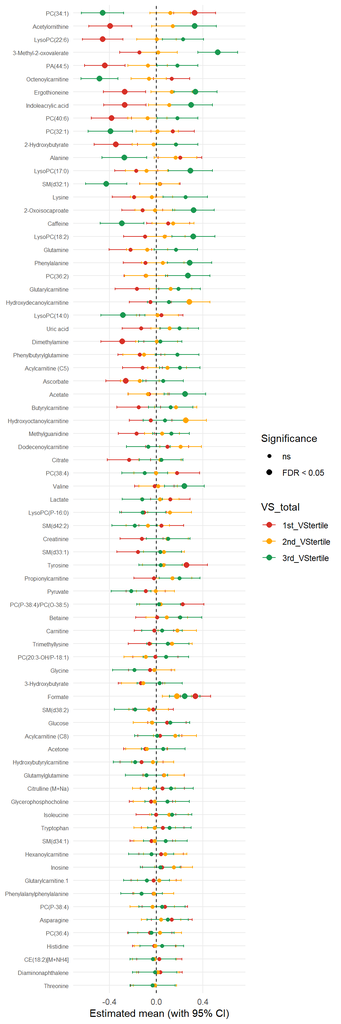

```r
# Define custom colours
VS_colors <- c("1st_VStertile"="#D73027",
               "2nd_VStertile"="orange",
               "3rd_VStertile"="#1A9850")

vs_effects <- merge(vs_effects,dispersion[,c("metabolite","range"),all.x=TRUE,by="metabolite"])

# Optional: order metabolites by mean effect size
forest_df <- vs_effects %>%
  group_by(metabolite) %>%
  mutate(range_eff = mean(range)) %>%
  ungroup()

forest_df$metabolite <- factor(
  forest_df$metabolite,
  levels = forest_df %>%
    arrange(range_eff) %>%
    pull(metabolite) %>%
    unique()
)

# Forest plot WITHOUT ANY TEXT LABELS
forest_df <- forest_df %>% mutate(sig = p_adj < 0.05)
p_forest <- ggplot(forest_df,
                   aes(x = emmean,
                       y = metabolite,
                       color = tertile_label)) +
  geom_errorbarh(aes(xmin = lower.CL, xmax = upper.CL), height = 0.2) +
  geom_vline(xintercept = 0, linetype = "dashed") +
  geom_point(size = 2.5,aes(shape = sig)) +
  scale_color_manual(values = VS_colors) +
  scale_shape_manual(values = c(`FALSE` = 20, `TRUE` = 19),   # 1 = open, 19 = solid
                     labels = c("ns", "FDR < 0.05"),
                     name   = "Significance") +
  theme_minimal() +
  theme(axis.title.y = element_blank(),
        axis.text.y = element_text(size = 6),
        panel.grid.minor = element_blank()) +

  labs(
    x = "Estimated mean (with 95% CI)",
    color = "VS_total"
  )

p_forest <- fix_labels(p_forest)

p_forest
```

```r
f <- p_forest
save(f,file="../results/vegan/figures/FS_VSForest.RData")
```

#### 4.2.2.5 Top-group assignment

**All together**

```r
VS_colors <- c("1st_VStertile"="#D73027",
               "2nd_VStertile"="orange",
               "3rd_VStertile"="#1A9850",
               "other"="gray70")

# Assign colors to nodes: countries get their color, metabolites gray
V(g)$color <- ifelse(V(g)$type,
                     VS_colors[V(g)$name],
                     "gray70")

top_group <- edges %>%
  dplyr::group_by(to) %>%
  slice_max(order_by = abs(weight), n = 1, with_ties = FALSE) %>%
  dplyr::select(from,to, weight) %>%
  ungroup()

top_group
```

```
# A tibble: 28 × 3
   from          to                     weight
   <chr>         <chr>                   <dbl>
 1 1st_VStertile 2-Hydroxybutyrate       0.345
 2 3rd_VStertile 2-Oxoisocaproate        0.318
 3 3rd_VStertile 3-Methyl-2-oxovalerate  0.526
 4 3rd_VStertile Acetate                 0.246
 5 1st_VStertile Acetylornithin          0.393
 6 3rd_VStertile Alanine                 0.272
 7 1st_VStertile Ascorbate               0.259
 8 3rd_VStertile Caffeine                0.293
 9 1st_VStertile Dimethylamine           0.290
10 3rd_VStertile Ergothionenine          0.336
# ℹ 18 more rows
```

```r
top_group_viz <- rbind(top_group,
                       data.frame(
                         from=unique(edges$from),
                         to=unique(edges$from),
                         weight=NA))

membership_df <- data.frame(
  vertex = top_group_viz$to,
  cluster = top_group_viz$from)

membership_df <- membership_df %>% arrange(match(vertex,names(V(g))))
```

```r
vs_clusters <- (membership_df %>%
  group_by(cluster) %>%
  summarise(metabolites = paste(unique(vertex), collapse = ", ")))[1:3,]

(membership_df %>%
  group_by(cluster) %>%
  summarise(Number_of_metabolites = length(unique(vertex))-1))[1:3,]
```

```
# A tibble: 3 × 2
  cluster       Number_of_metabolites
  <chr>                         <dbl>
1 1st_VStertile                     9
2 2nd_VStertile                     2
3 3rd_VStertile                    17
```

```r
vs_clusters
```

```
# A tibble: 3 × 2
  cluster       metabolites
  <chr>         <chr>
1 1st_VStertile 1st_VStertile, PA.44.5., PC.40.6., LysoPC.22.6., Acetylornithin…
2 2nd_VStertile 2nd_VStertile, Hydroxydecanoylcarnitine, Hydroxyoctanoylcarniti…
3 3rd_VStertile 3rd_VStertile, Caffeine, PC.32.1., PC.34.1., PC.36.2., SM.d32.1…
```

```r
V(g)$fill <- VS_colors[membership_df$cluster]
V(g)$color <- VS_colors[membership_df$cluster]
```

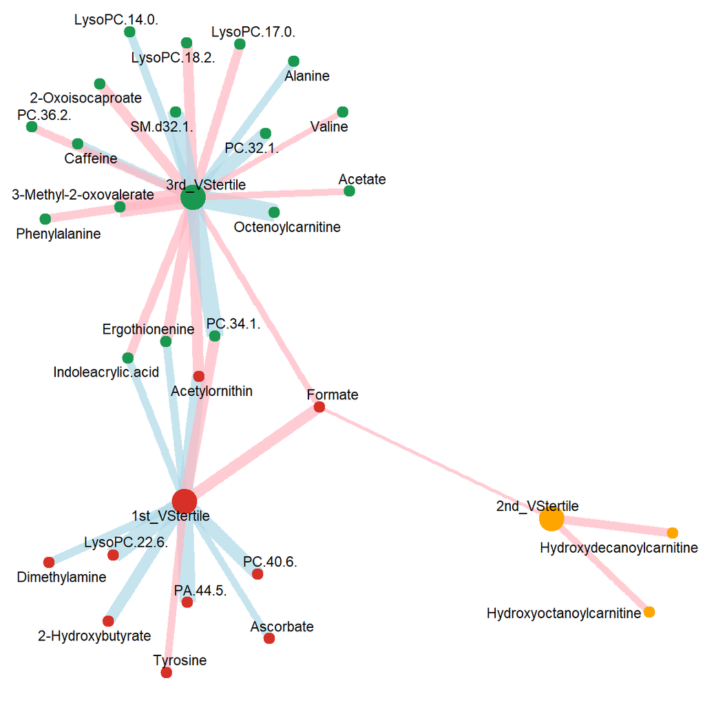

```r
set.seed(123)
p_all <- ggraph(g, layout = "fr") +
  geom_edge_link(aes(width = abs(weight), color = emmean > 0), alpha = 0.7) +
  scale_edge_color_manual(values = c("lightblue","lightpink"),labels = c("<0", ">0")) +
  geom_node_point(aes(size=type,color = name,fill=name),shape=21,stroke=1.2) +
  scale_color_manual(values = setNames(V(g)$color, V(g)$name))   + # node colors
  scale_fill_manual(values = setNames(V(g)$fill, V(g)$name)) +  # node fill
  geom_node_text(aes(label = name), repel = TRUE, size = 3) +
  theme_void() +
  theme(legend.position = "none")


p_all
```

# 5 Final significant metabolites

```r
list_core <- list()

list_core[["concat_univariate"]] <- unique(concat_significant)
```

```r
final_significance <- list_core[["concat_univariate"]]
final_significance
```

```
[1] "PA.44.5."           "PC.34.1."           "PC.40.6."
[4] "SM.d42.2."          "LysoPC.22.6."       "Indoleacrylic.acid"
[7] "LysoPC.17.0."       "Ergothionenine"     "Acetylornithin"
```

# 6 Metabolite-based veganscreener score

## 6.1 Continuous univariate test

To build a vegan index from the concatenated dataset, we use linear regression to obtain coefficients for the significant variables identified across the analysis:

```r
sign <- final_significance
sign
```

```
[1] "PA.44.5."           "PC.34.1."           "PC.40.6."
[4] "SM.d42.2."          "LysoPC.22.6."       "Indoleacrylic.acid"
[7] "LysoPC.17.0."       "Ergothionenine"     "Acetylornithin"
```

```r
# define the variables
plot_list <- list()
rhos <- rep(NA,5)
ps <- rep(NA,5)

# split the datasets for cross-validation
concat_for_index <- concat_for_uni[sample(rownames(concat_for_uni)),]
cv_splits <- cv_folds(concat_for_index,folds = 5)

final_df_veganindex <- data.frame()

# cross validation loop
vars_selection <- list()
for (i in 1:length(cv_splits)){
  unisub_df <- concat_for_uni[cv_splits[[i]]$train,]
  results_list <- lapply(colnames(concat_integrated_df),
                       function(x) fit_glm(x,unisub_df,
                                           tested_variable = "VS_total"))
  results_df <- do.call(rbind, results_list)

  results_df$p_adjusted <- p.adjust(results_df$Pr...t..,method = "BH")

  vars <- results_df$metabolite[results_df$p_adjusted<0.05 & results_df$variable=="VS_total"]
  vars_selection[[i]] <- vars

  # Wrap all variable names in backticks
  vars_safe <- paste0("`", vars, "`")

  fml <- as.formula(paste("VS_total ~", paste(vars_safe, collapse = " + ")))

  # fit the model
  model <- lm(fml, unisub_df)

  # predict the result on validation dataset
  VG_index <- stats::predict(model,concat_for_uni[cv_splits[[i]]$val,])

  # store the predicted index
  sub_df <- concat_for_uni[cv_splits[[i]]$val,]
  sub_df$VGindex <- VG_index
  final_df_veganindex <- rbind(final_df_veganindex,sub_df)

  # calculate correlation
  cor_test <- cor.test(sub_df$VGindex,
               sub_df$VS_total,
               method = "spearman")
  cor_val <- cor_test$estimate
  if (cor_test$p.value >0.05) cor_val = 0

  # plot the result
  p <- ggplot(sub_df,
              aes_string(x = "VGindex", y = "VS_total"),
              color="blue") +
       geom_point() +
    geom_smooth(method = "lm") +
    theme_minimal() +
    ggtitle(paste("Rho =",round(cor_val,2)))

  plot_list[[i]] <- p
  rhos[i] <- round(cor_val,2)
  ps[i] <- cor_test$p.value
}
```

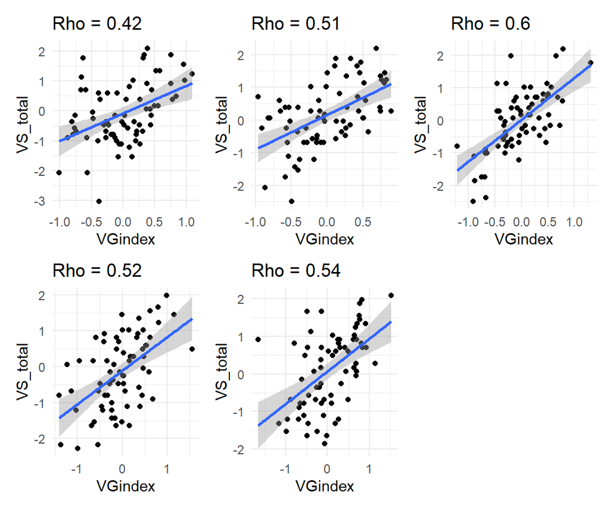

```r
wrap_plots(plot_list)
```

```r
mean(rhos)
```

```
[1] 0.518
```

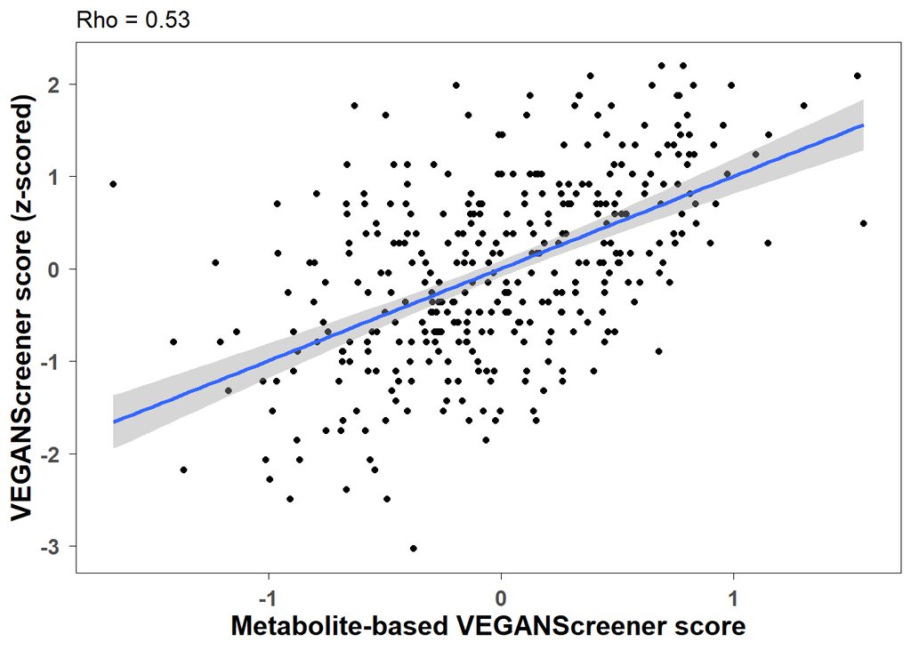

```r
# calculate correlation
  cor_test <- cor.test(final_df_veganindex$VGindex,
               final_df_veganindex$VS_total,
               method = "spearman")
  cor_val <- cor_test$estimate
  if (cor_test$p.value >0.05) cor_val = 0

  # plot the result
  p <- ggplot(final_df_veganindex,
              aes_string(x = "VGindex", y = "VS_total"),
              color="blue") +
       geom_point() +
    geom_smooth(method = "lm") +
    theme_minimal() +
      theme(panel.border =
              element_rect(color = "black", fill = NA, size = 0),
            panel.grid = element_blank(),
            axis.ticks.x =
              element_line(size=0.3,color = "black"),
            axis.ticks.y =
              element_line(size=0.3,color="black"),
            axis.ticks.length = unit(4,"pt"),
            axis.text=element_text(face="bold",size=12),
            axis.title = element_text(face="bold",size=15)) +
    ggtitle(paste("Rho =",round(cor_val,2))) +
    xlab("Metabolite-based VEGANScreener score") +
    ylab("VEGANScreener score (z-scored)")

p
```

```r
# Fisher's method to combine p-values
library(metap)
combined_p <- sumlog(ps)$p
combined_p
```

```
[1] 1.31167e-22
```

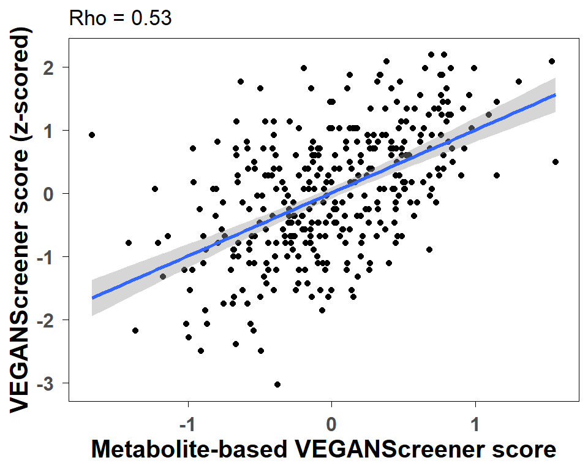

```r
p
```

```r
f <- p + ggtitle("")
save(f,file="../results/vegan/figures/F5b_VMI.RData")
```

# 7 Plot for publication

## 7.1 Heatmap

### 7.1.1 Continuous

```r
ordered_participants <- metadata_df %>%
  dplyr::arrange(VS_total)

concat_significant_df <- concat_significant_df %>%
  dplyr::filter(metabolite %in% final_significance) %>%
  dplyr::arrange(Estimate)

heatmap_concat_integrated_df <- concat_integrated_df

heatmap_concat_integrated_df <- heatmap_concat_integrated_df[as.character(ordered_participants$study_id),
                             as.character(concat_significant_df$metabolite)]

# Create a grouping variable for each block of 10 rows
group_id <- rep(1:ceiling(nrow(heatmap_concat_integrated_df) / 10), each = 10,
                length.out = nrow(heatmap_concat_integrated_df))

# Calculate the mean for each group
df_grouped <- aggregate(heatmap_concat_integrated_df,
                        by = list(Group = group_id), FUN = median)

# Remove the Group column name prefix if you want just the values
rownames(df_grouped) <- paste0("Group_", df_grouped$Group)
df_grouped$Group <- NULL
```

```r
df_long <- df_grouped %>% t() %>% as.data.frame() %>%
  rownames_to_column("Metabolite") %>%
  pivot_longer(cols = -Metabolite, names_to = "Participant", values_to = "value")

df_long$Metabolite <- factor(df_long$Metabolite, levels=concat_significant_df$metabolite)
df_long$Participant <- factor(as.character(df_long$Participant), levels=paste0("Group_",1:37))


p_heat <- ggplot(df_long, aes(x = Participant, y = Metabolite, fill = value)) +
  geom_tile(color = "white",width=1) +
  theme_minimal() +
  theme(axis.text.x = element_blank(),
        axis.title.x = element_text(face = "bold",size = 9),
        axis.text.y = element_blank(),
        panel.grid = element_blank(),
        legend.position = "right") +
  labs(fill = "Median metabolite z-score") +
  xlab("Vegans (ordered and grouped by VEGANScreener score)") +
  ylab("") +
  scale_fill_gradient2(
    low = "darkcyan", mid = "white", high = "brown", midpoint = 0)

# get legend
leg_heat_p <- ggpubr::get_legend(p_heat)

# remove legend
p_heat <- p_heat + theme(legend.position = "right")
```

```r
annotation_df <- concat_significant_df
annotation_df$metabolite <- factor(annotation_df$metabolite,
                                   levels=annotation_df$metabolite)


ann_p <- ggplot(
  data=annotation_df,
  aes(x = "Estimate", y = metabolite, fill = Estimate)) +
  geom_tile(color = "white") +
  scale_fill_gradient2(low = "#313695", mid = "white", high = "#A50026", midpoint = 0) +
  theme_minimal() +
  theme(axis.text.y = element_text(face = "bold"),
        axis.text.x = element_blank(),
        axis.title.y= element_text(face = "bold"),
        axis.ticks = element_blank(),
        panel.grid = element_blank(),
        legend.position = "right") +
  ylab("Significant metabolites") +
  xlab("") +
  labs(fill="LM estimate")

ann_p <- fix_labels(ann_p)

# get legend
leg_ann_p <- ggpubr::get_legend(ann_p)

# Remove legend from the original plot
ann_p <-ann_p + theme(legend.position = "right")
```

```r
# correlations
df_for_plot <- concat_integrated_df %>% dplyr::select(final_significance)
df_for_plot <- df_for_plot[,concat_significant_df$metabolite]
corr_object <- cor(concat_for_uni$VS_total,df_for_plot,method="spearman")
corr_df <- data.frame(Metabolite=colnames(corr_object),
                      Rho=corr_object[1,])
corr_df$Metabolite <- factor(corr_df$Metabolite,
                             levels=corr_df$Metabolite)

p_corr <- ggplot(corr_df) +
  geom_point(aes(x="Rho",y= Metabolite,size = abs(Rho), fill = Rho, color=Rho),
             shape = 21) +
  scale_fill_gradient2(name = "Rho",
                       low = "blue", mid = "white", high = "red", midpoint = 0) +
    scale_color_gradient2(name = "Rho",
                          low = "blue", mid = "white",
                          high = "red", midpoint = 0) +
  guides(size = "none") +
  theme_minimal() +
  theme(axis.text.y = element_blank(),
        axis.text.x = element_blank(),
        axis.title.y= element_blank(),
        axis.ticks = element_blank(),
        panel.grid = element_blank(),
        legend.position = "right") +
  xlab("")


leg_corr_p <- ggpubr::get_legend(p_corr)

# Remove legend from the original plot
p_corr <-
  p_corr +
  theme(
    legend.position = "right")
```

```r
legends <- ggarrange(leg_heat_p, leg_ann_p, leg_corr_p,nrow = 3, align = "hv")

p <- wrap_plots(ann_p,p_corr,p_heat,legends,ncol=4,widths = c(0.1,0.15, 1, 1))
```

```r
cbar <- guide_colourbar(barheight = unit(1.8, "cm"),
                        barwidth  = unit(0.35, "cm"),
                        title.position = "top")

p_heat <- p_heat + guides(fill   = cbar)   # z-score (fill)
ann_p  <- ann_p  + guides(fill   = cbar)   # LM estimate (fill)
p_corr <- p_corr + guides(fill = cbar)   # Rho (colour, not fill)

p <- wrap_plots(ann_p, p_corr, p_heat, ncol = 3, widths = c(0.1, 0.15, 1)) +
  plot_layout(guides = "collect") &
  theme(legend.position  = "right",
        legend.box       = "vertical",
        legend.title     = element_text(size = 9, face = "bold"),
        legend.text      = element_text(size = 8))
```

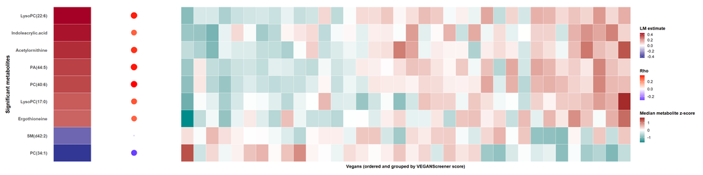

```r
p
```

```r
f <- p
save(f,file="../results/vegan/figures/FS_VSheatmap.RData")
```

### 7.1.2 Pairwise

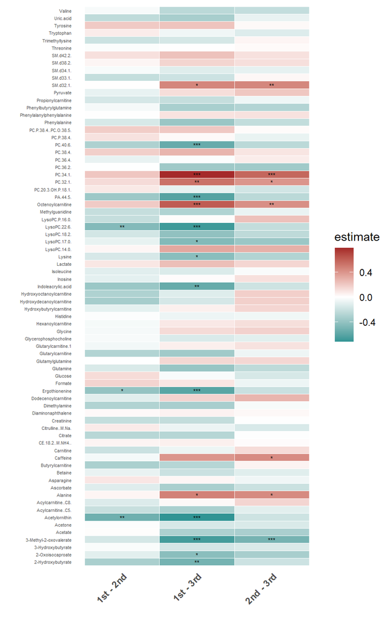

```r
p_pairwise_heatmap
```

## 7.2 Forest plot

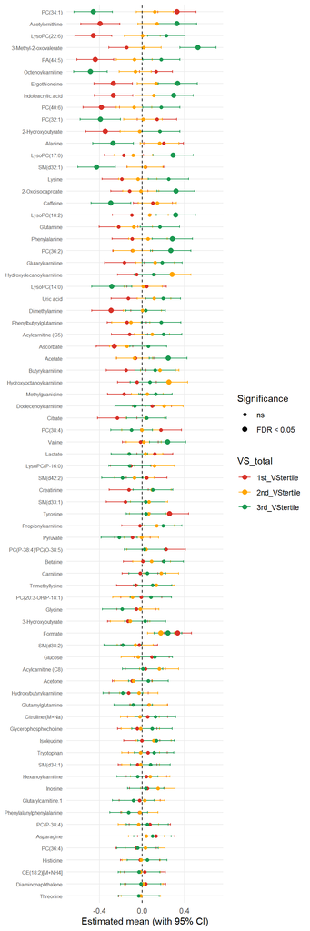

```r
p_forest
```

```r
save(p_forest,file = "../results/vegan/figures/FS2.RData")
```

## 7.3 Network

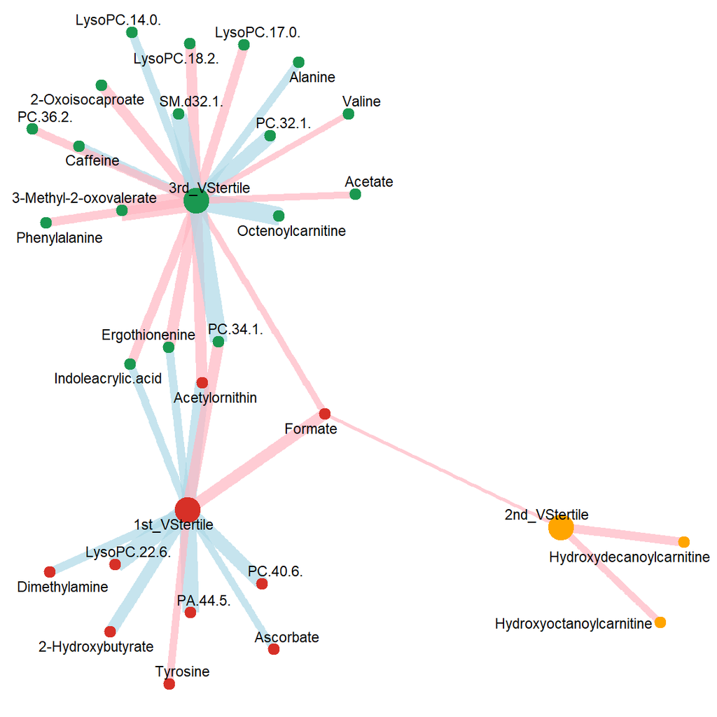

```r
p_all
```